# Class 5: Internal Organisation and Incentives

MG106 Strategic Management

José Ignacio González Rojas

j.i.gonzalez-rojas@lse.ac.uk

London School of Economics and Political Science

June 29, 2026

## Nordstrom shows how measurement can undermine a service strategy

### Service strategy creates work that SPH only partly measures

Nordstrom competes through service, but the SPH system measures only part of the work that creates service quality.

Today: diagnose how metrics, incentives, management, and culture interact.

## Four questions diagnose Nordstrom’s organisational system

### Metrics, incentives, management, and culture interact

#### Four questions for today

1. **Root causes:** what created these problems, and how serious are they?
2. **Pressure sources:** SPH system, management behaviour, or both?
3. **Memo effectiveness:** does Exhibit 3 clarify sell/non-sell time?
4. **System redesign:** how would you fix compensation and policies?

**Concept:** internal organisational system = metrics + incentives + culture + structure

**Task:** infer which system element changes behaviour

**Analyse the system**

*Start with Nordstrom’s business model*

# Nordstrom’s business model depended on service-oriented human capital

## Nordstrom’s WHO-WHAT-HOW made employees the key resource

### The business model requires service work before and after transactions

#### WHO

- Affluent customers
- Value relationships
- Seek expertise
- Time-sensitive

#### WHAT

- Personal service
- Fashion expertise
- “Heroics”
- Convenience

#### HOW

- College-educated staff
- High compensation
- Entrepreneurial culture
- SPH system

**Key resource:** service-oriented employees earning above industry average

How do you manage service work that is hard to observe?

# The root cause was a mismatch between service work and measured work

## SPH made selling hours visible and other service work costly

### A monitored productivity metric creates behavioural pressure

#### What SPH measures

- Sales ÷ Hours = Productivity
- Individual performance
- Commission threshold logic (example target: $140/hr)
- Relative rankings

#### The trade-offs (page 6)

| Choice | Result | Impact |
| --- | --- | --- |
| Report less hours | Higher SPH | Better shifts |
| Report all hours | Lower SPH | Risk termination |

What work becomes invisible when SPH dominates?

## Hidden service work created the central misalignment

### Two essential activities, one measurement system

#### Measured activities

- Floor selling
- Direct transactions
- Immediate revenue
- Visible to system

#### Unmeasured activities

- Home deliveries
- Thank-you notes
- Relationship building
- Stock preparation

**The misalignment:** both create value, only one counts

Media-reported claims: 8–10 off-clock hours/week among claimants

## The internal measurement problem became an external strategic threat

### Reputation, legal exposure, and employee trust were all at risk

#### Escalation path

- Local union complaints
- State investigation
- Management response
- Employee lawsuits
- Media coverage

#### Damage scale

- Over $2M in collected back-pay claims
- Wage violations ruling
- $15M back-wage reserve
- Class-action exposure
- National exposure

**Resource at risk:** 90-year reputation

Intangible assets can erode quickly

# SPH and management practice reinforced each other

## Pressure came from the organisational system, not one isolated rule

### Incentives, structure, culture, and people jointly shaped behaviour

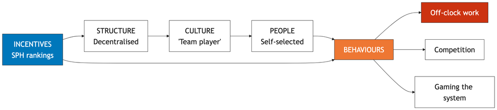

## Management practice translated SPH into day-to-day pressure

### The system mattered, but managers made the pressure concrete

#### Implicit pressures

- Public rankings posted
- Schedule assignments
- Promotion decisions
- “Team player” culture

#### Explicit actions (per case)

- Managers erase hours
- Alleged unpaid meetings
- Penalise full reporting
- Create fear of penalty

Identify one pressure from SPH and one from management behaviour.

# Exhibit 3 clarified categories but did not fix incentives

## Exhibit 3 failed because classification did not remove SPH pressure

### Clarifying categories does not change the payoff to under-reporting

#### What the memo clarified

- “All employees will be paid for time worked”
- Hand-carries and home deliveries can be compensable
- Stock work, thank-you notes, customer correspondence, committees, seminars, and mandatory meetings may count as work

#### What the memo did not change

- Reporting non-sell time still reduces measured SPH
- Managers still interpret the system locally
- Employees still face pressure between service expectations and reported hours

Clarification helps only if incentives make honest reporting safe.

# Redesign has to protect service while reducing distortion

## Better metrics must measure the service model, not only sales speed

### Measurement should track the activities that create strategic value

#### Current state

- Sales per hour only
- Individual focus
- Short-term view

#### Add metrics for

- Customer retention
- Transaction value
- Team performance
- Service quality

Which new metric would change behaviour without killing service?

## Organisational alignment means preserving culture while fixing incentives

### The redesign should keep what makes Nordstrom valuable

#### Keep

- Entrepreneurial spirit
- Performance differentiation
- Customer focus
- High standards

#### Change

- Broaden metrics
- Team incentives
- Clear boundaries
- Ethical guidelines

**Key:** preserve service culture while fixing misaligned expectations

Adapt the system without losing the service model

# Strategic implication: internal systems make resources valuable

## Service culture is a resource only if the system sustains it

### Internal systems must protect intangible assets

#### Tangible resources

- 59 store locations
- Distribution systems
- Financial capital
- Physical inventory

#### Intangible resources

- Brand reputation (90 years)
- Customer relationships
- Service culture
- Employee expertise

Which resources become weaker when employee trust erodes?

## Internal organisation works when strategy, behaviour, and metrics reinforce each other

### System alignment is critical

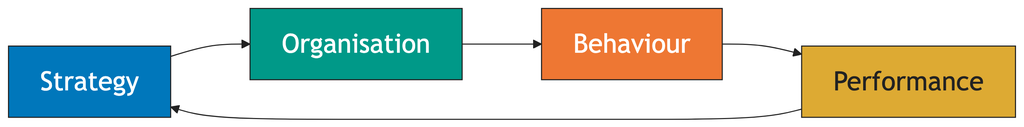

#### The Nordstrom case shows

Good strategy + misaligned organisation = poor outcomes

Name the weakest link in Nordstrom’s system.

## The lesson is to design metrics around the strategy they serve

### For strategic management

#### Measurement

- Shapes behaviour
- Must be complete
- Creates distortions

#### Culture

- Competitive advantage
- Takes time to build
- Easy to damage

#### Alignment

- All elements matter
- Must reinforce
- System coherence

Excellence requires coherent systems

## For tomorrow, read Apple as a resources-and-capabilities case

**Apple 2010**

**Read**: The Apple case

**Questions to consider:**

1. What have been Apple’s competitive advantages?
2. How favourable is the PC industry for Apple?
3. How sustainable is Apple’s position in PCs, smartphones, iPads?

**Focus on**: How resources and capabilities create advantage